# PSTAT 131 Final Project Predicting Myopia

Christian Solares

2026-05-10

## Introduction

Myopia, also known as nearsightedness, is a condition that prevents clear focusing on distant objects but allows for clear vision of nearby objects. Nearsightedness can develop early in childhood and can worsen over time. Accurately predicting the risk of children developing myopia would ensure they are provided with necessary vision care. This is particularly important because uncorrected myopia can result in permanent strain and headaches, and is the most common reason for visual impairment in children. (Congdon, Burnett, and Frick 2019)

For this project, I planned to create a classifier model which predicts whether a child becomes myopic within the next five years. Specifically, this model will be built using variables which are obtainable through examination and survey responses. Since developing myopia was not common in the data, it would negatively affect the models. I addressed this by training models with and without oversampling. I compare four classifiers, logistic regression, linear discriminant analysis, k-nearest neighbors and elastic net regularized logistic regression using 10-fold cross validation and evaluate them mostly by ROC AUC.

## Data Description

The dataset I use for this project was sourced from bekkabratch/aps-clone. It is part of the Orinda Longitudinal Study of Myopia (OLSM). OLSM was the name of a real-life study that began in 1989 and looked at ocular development and risk factors in children. This particular subset of the data was also used in the textbook Applied Logistic Regression by Hosmer, Lemeshow, and Sturdivant (2013).

The dataset includes information on 618 individuals who were non-myopic at the start of the experiment and participated in the study for at least five years. My dependent variable is called myopic, which tells us whether the child became myopic or not during the first five years of the study. Therefore, this is a binary dependent variable with two values (Yes and No). Since only about 13% of the children in the dataset became myopic, I need to oversample the data. In this project, I address this by building classification models both with and without oversampling. The downsides to this is oversampling can lead to overfitting, but this ultimately improved the predictions of my models.

## Inspiration

My main motivation for this project is that I’m nearsighted, and both of my parents wear glasses too. However, both my sister and brother don’t use glasses for near or farsightedness. Thus, being personally interested in this topic, I wanted to find out to what extent my parents’ myopia influenced my case and what my chances would be to avoid myopia. Another reason why I found this project interesting is because it utilizes real world factors that contribute to myopia. Beyond building a model, this project was a valuable learning experience about what causes myopia and how eye doctors and researchers study it.

[figure not shown]

## Codebook

Here is the list of the variables and a short description of each variable from the github page:

- id: Study ID
- studyyear: Year subject entered the study
- myopic: Myopia within the first five years of follow up [No = 0, Yes = 1]
- age: Age at first visit (years) [5, 6, 7, 8, and or 9]
- gender: Gender [Male = 1, Female = 0]
- spheq: Spherical Equivalent Refraction (diopter)
- al: Axial Length (mm)
- acd: Anterior Chamber Depth (mm)
- lt: Lens Thickness (mm)
- vcd: Vitreous Chamber Depth (mm)
- sporthr: Time spent engaging in sports/outdoor activities (hours per week)
- readhr: Time spent reading for pleasure (hours per week)
- comphr: Time spent playing video/computer games or working on the computer (hours per week)
- studyhr:Time spent reading or studying for school assignments (hours per week)
- tvhr: Time spent watching television (hours per week)
- diopterhr: Composite of near-work activities (hours per week)
- mommy: Was the subject’s mother myopic? [No = 0, Yes = 1]
- dadmy: Was the subject’s father myopic? [No = 0, Yes = 1]

(Here I used deepseek to help me understand how to put these images side by side)

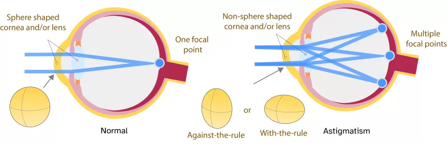

Figure 1: Spherical Equivalent Refraction (spheq)

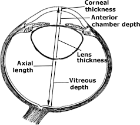

Figure 2: Ocular measurements: Axial Length (al), Anterior Chamber Depth (acd), Lens Thickness (lt), Vitreous Chamber Depth (vcd)

## Exploratory Data Analysis (EDA)

### Reading and Understanding Data

```r
set.seed(888)
# csv file is downloaded from
# https://github.com/JLFDataScience/myopia_prediction/tree/master
# myopia_data <- read.csv("C:/Users/csola/OneDrive/Desktop/Pstat 131/Final project folder/Myopia dataset stuff/MYOPIA.csv")

# but I found a problem where this person categorized gender for
# example as 1 or 0 without specifying which is which, so I found the original dataset here:
# https://github.com/bekkabratch/aps-clone/blob/master/data/myopia.rda

load("C:/Users/csola/OneDrive/Desktop/Pstat 131/Final project folder/Myopia dataset stuff/original_myopia_data.rda")
# loading an .rda saved the data as "myopia", but I want to change the name to myopia_data
myopia_data <- myopia
any(is.na(myopia_data)) # FALSE
summary(myopia_data)
head(myopia_data)
nrow(myopia_data)
```

There is no missing values in this dataset.

### Cleaning data

```r
# First before anything I need to remove "id" and "studyyear"
library("dplyr")
edited_myopia_data <- select(myopia_data, -id, -studyyear)
# head(edited_myopia_data)
# here I make these four variables numeric instead of factors.
edited_myopia_data <- mutate(edited_myopia_data,
myopic = as.numeric(myopic == "Yes"), # 1 = myopic, 0 = not
    gender = as.numeric(gender == "Male"), # 1 = Male, 0 = Female
    mommy  = as.numeric(mommy == "Yes"),
    dadmy  = as.numeric(dadmy == "Yes"))
# 0 = no, 1 = yes
head(edited_myopia_data)
summary(edited_myopia_data)
```

Here as stated in the comments, I make these four variables numeric instead of factors. And I removed id and studyyear because they are not important to analyze.

### Correlation Plot

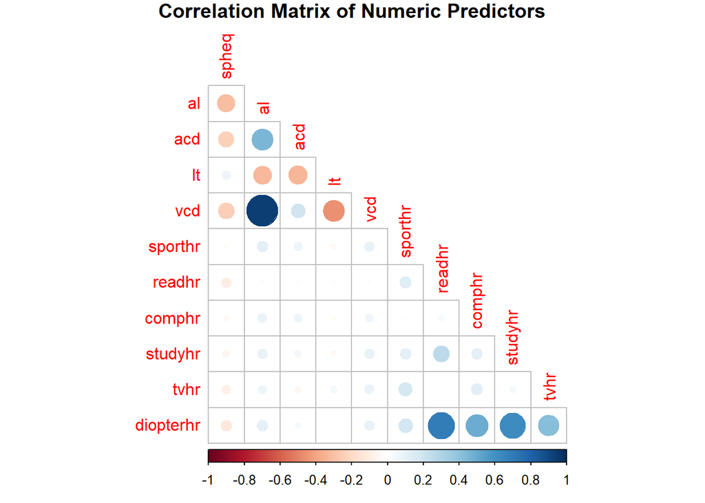

```r
library("corrplot")
# I removed these variables because they were not continuous numeric variables.
continous_edited_myopia_data <- select(edited_myopia_data, -age, -myopic, -gender, -mommy, -dadmy)

cor_matrix <- cor(continous_edited_myopia_data)
corrplot(cor_matrix, type = "lower",
         diag = FALSE,
         title = "Correlation Matrix of Numeric Predictors",
         mar = c(0,0,1,0)) # adjust title margin, without it, title is cut off.
```

### Distribution of Myopia Outcome (No, Yes)

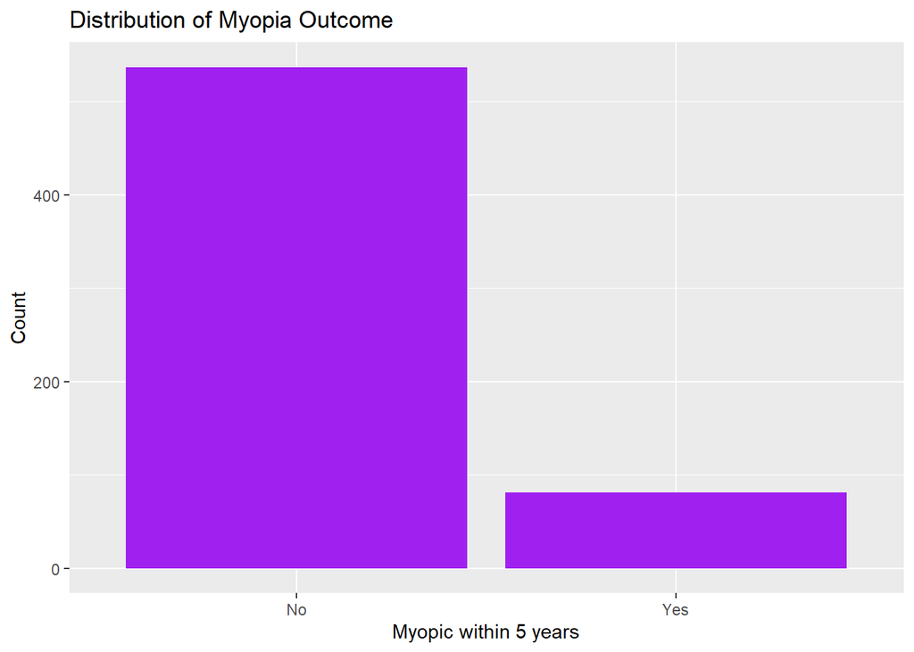

```r
library("ggplot2")
ggplot(edited_myopia_data, aes(x = factor(myopic,
                                          labels = c("No", "Yes")))) +
    geom_bar(fill = "purple") +
    labs(title = "Distribution of Myopia Outcome",
         x = "Myopic within 5 years", y = "Count")
```

I could use undersampling or oversampling here because there are so little yes. After seeing the results of the models, I decided to use oversampling and compare the results.

### Boxplots of Continuous Predictors

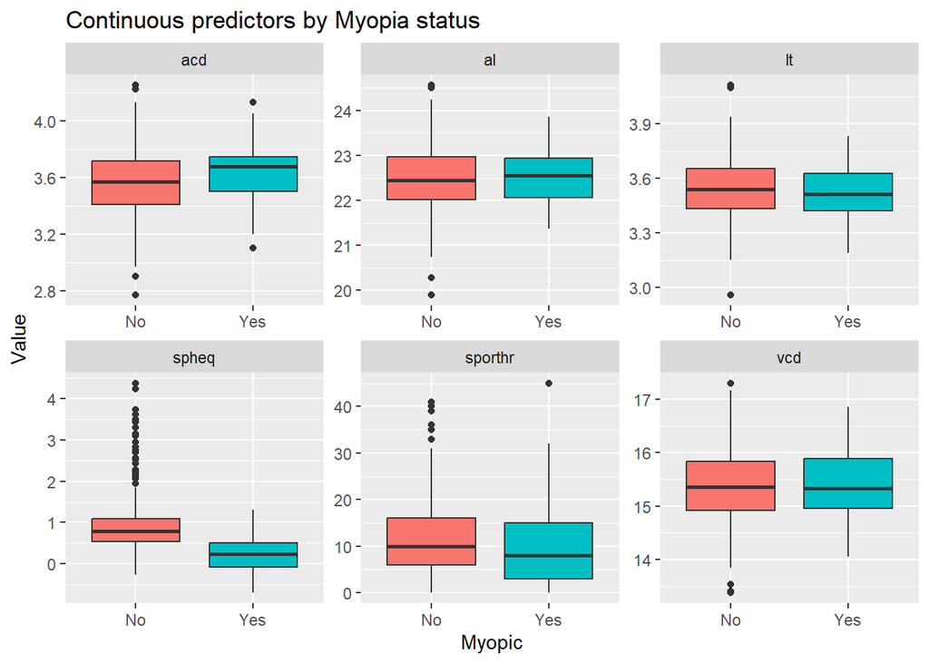

```r
library("ggplot2")
library("tidyr")
# Deepseek was used, I needed a way to fit multiple boxplots into one output. facet_wrap() was suggested.
edited_myopia_data %>%
    pivot_longer(cols = c(spheq, al, acd, lt, vcd, sporthr),
                 names_to = "Predictor", values_to = "Value") %>%
    ggplot(aes(x = factor(myopic, labels = c("No", "Yes")),
               y = Value, fill = factor(myopic))) +
    geom_boxplot() +
    facet_wrap(~Predictor, scales = "free") +
    labs(title = "Continuous predictors by Myopia status", x = "Myopic") +
    theme(legend.position = "none")
```

### Histograms of Predictors

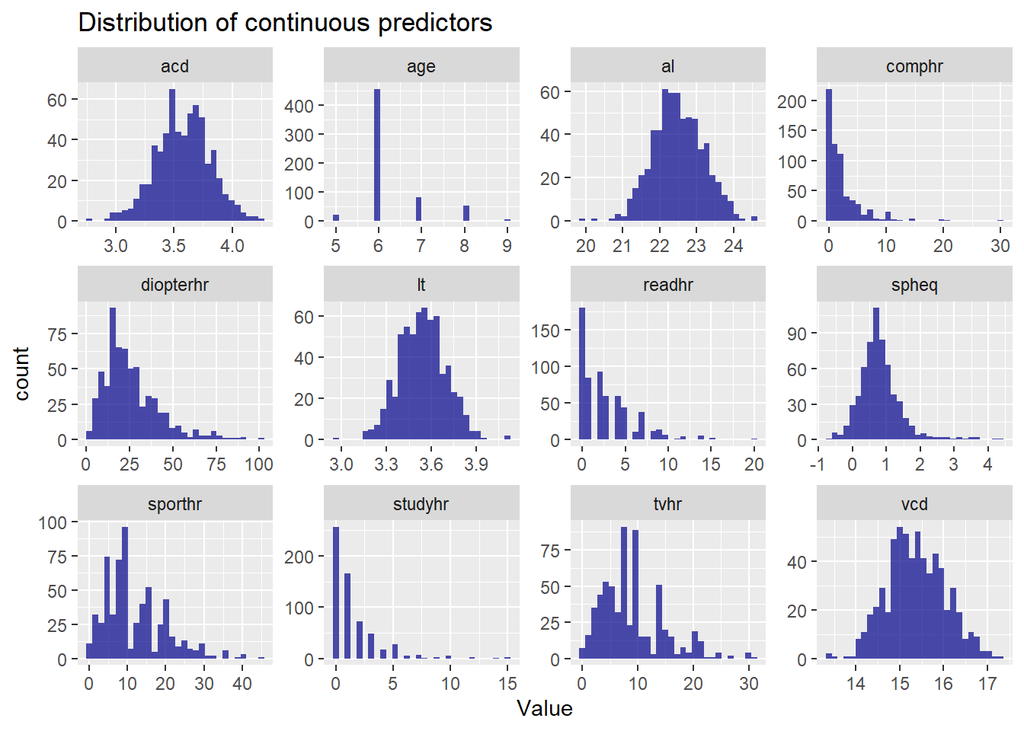

```r
edited_myopia_data %>%
    select(age, spheq, al, acd, lt, vcd, sporthr, readhr, comphr, studyhr,
           tvhr, diopterhr) %>%
    pivot_longer(everything(), names_to = "Variable", values_to = "Value") %>%
    ggplot(aes(x = Value)) +
    geom_histogram(bins = 30, fill = "darkblue", alpha = 0.7) +
    facet_wrap(~Variable, scales = "free") +
    labs(title = "Distribution of continuous predictors")
```

The approximately normal histograms are acd, al, lt, vcd, and spheq (spheq is right skewed). the histograms that right skewed are sporthr, readhr, comphr, studyhr, tvhr, and diopterhr. And what stands out to me is that most children are age 6 by a large margin.

### Proportion of Myopic Children Based on Parental Myopia

```r
# I wanted to use this table seen in lab 2
library("kableExtra")
parental_table <- edited_myopia_data %>%
    group_by(mommy, dadmy) %>%
    summarise(n = n(), prop_myopic = mean(myopic), .groups = "drop") %>%
    mutate(mommy = ifelse(mommy == 1, "Mom myopic", "Mom not"),
           dadmy = ifelse(dadmy == 1, "Dad myopic", "Dad not"))

parental_table %>%
    kable(caption = "Proportion of myopic children by parental myopia") %>%
    kable_styling()
```

Proportion of myopic children by parental myopia

| mommy | dadmy | n | prop_myopic |
| --- | --- | --- | --- |
| Mom not | Dad not | 152 | 0.0328947 |
| Mom not | Dad myopic | 153 | 0.1372549 |
| Mom myopic | Dad not | 158 | 0.1265823 |
| Mom myopic | Dad myopic | 155 | 0.2258065 |

Based on my data, this table shows that when neither parent is myopic, only about 3.3% of children developed myopia. This serves as the baseline risk. When exactly one parent is myopic, the proportion increases to approximately 13% to 14%. When both parents are myopic, the proportion jumps to 22.58%, nearly seven times higher than the baseline.

## Data Splitting

```r
# I made myopic numeric, now I need to change it back to a factor
model_data <- edited_myopia_data %>%
    mutate(myopic = factor(myopic, levels = c(0, 1), labels = c("No", "Yes")))

library(rsample)
myopia_split <- initial_split(model_data, prop = .75, strata = myopic)
myopia_train <- training(myopia_split)
myopia_test  <- testing(myopia_split)

myopia_folds <- vfold_cv(myopia_train, v = 10, strata = myopic)
```

I decided to use 75% because there are only 81/618 myopia = yes outcomes. So having 25% in the test set ensures that we have enough yes outcomes in the test set. I also chose v = 10 because as stated in the lecture, usually around 5-10 folds performs the best on real world data in general. How vfold_cv() works is we split our data into 10 equal groups not in any order. We train the model on 9 of the folds and test it on the remaining 1 fold, repeating this 10 times so each fold gets a turn as the test set. But the downside to this method is depending on the number of folds and the ammound of data, there can be a big computation time. And you want to avoid doing k = n folds.

## Processing for KNN and Elastic Net

```r
library(recipes)
myopia_recipe <- recipe(myopic ~ ., data = myopia_train) %>%
    step_normalize(all_numeric_predictors())
```

We need to create this recipe because the models KNN and elastic net need the functions to be scaled. I used all_numeric_predictors() instead of all_predictors() to avoid accidentally trying to scale non‑numeric columns like myopic which we changed back to a factor.

## Logistic regression

```r
library(parsnip)
library(workflows)
library(tune)
library(yardstick)
log_spec <- logistic_reg() %>%
    set_engine("glm") %>%
    set_mode("classification")

log_wf <- workflow() %>%
    add_recipe(myopia_recipe) %>%
    add_model(log_spec)

log_cv <- fit_resamples(log_wf, resamples = myopia_folds,
                        metrics = metric_set(roc_auc, accuracy))
```

This model works well when relationships are similar to being linear.

## LDA

```r
library(discrim)
lda_spec <- discrim_linear() %>%
    set_engine("MASS") %>%
    set_mode("classification")

lda_wf <- workflow() %>%
    add_recipe(myopia_recipe) %>%
    add_model(lda_spec)

lda_cv <- fit_resamples(lda_wf, resamples = myopia_folds,
                        metrics = metric_set(roc_auc, accuracy))
```

```
## → A | warning: variables are collinear
```

[output not shown]

Some predictors are highly correlated. LDA can still run, but the warning indicates instability. The issues with some computation does not mean the model is invalid, but it does suggest that the results should be interpreted with caution. This model works similar to linear regression where it assumes predictors follow a normal distribution. And this model becomes more stable the smaller the sample size.

## QDA

```r
qda_spec <- discrim_quad() %>%
    set_engine("MASS") %>%
    set_mode("classification")

qda_wf <- workflow() %>%
    add_recipe(myopia_recipe) %>%
    add_model(qda_spec)

qda_cv <- fit_resamples(qda_wf, resamples = myopia_folds,
                        metrics = metric_set(roc_auc, accuracy))
```

```
## → A | error:   rank deficiency in group No
```

[output not shown]

```
## There were issues with some computations   A: x10
```

QDA failed due to “rank deficiency in group No” The myopic = Yes group has only 81 yes in full data and even fewer in training folds. QDA requires estimating a separate covariance matrix for each class, but the small sample size doesn’t work well. Therefore, QDA cannot be used on this dataset.

## KNN (tune neighbors)

```r
library(kknn)
library(dials)
knn_spec <- nearest_neighbor(neighbors = tune()) %>%
    set_engine("kknn") %>%
    set_mode("classification")

knn_wf <- workflow() %>%
    add_recipe(myopia_recipe) %>%
    add_model(knn_spec)

knn_grid <- grid_regular(neighbors(range = c(3, 31)), levels = 15)

knn_cv <- tune_grid(knn_wf, resamples = myopia_folds, grid = knn_grid,
                    metrics = metric_set(roc_auc))
# I don't have to use save() and load() because the
# models run time is very short.
```

How the KNN model works is the model makes predictions by looking at the “k” children in the training data with the most similar variables. It then votes on if those “k” children developed myopia. My range is from 3-31 because starting at 1 or 2 is less reliable. I chose 31 because in the training set, we have 618 x .75 = about 464 observations and sqrt(464) is about = 21, but I wanted to be more thorough and see if smoothing with even more neighbors could improve performance so I extended the range to 31.

## Elastic Net Logistic Regression (tune penalty and mixture)

```r
en_spec <- logistic_reg(penalty = tune(), mixture = tune()) %>%
    set_engine("glmnet") %>%
    set_mode("classification")

en_wf  <- workflow() %>%
    add_recipe(myopia_recipe) %>%
    add_model(en_spec)

en_grid <- grid_regular(
    penalty(range = c(0, 1), trans = identity_trans()),
    mixture(range = c(0, 1)),
    levels = 10)

en_cv <- tune_grid(en_wf, resamples = myopia_folds, grid = en_grid,
                   metrics = metric_set(roc_auc))
```

How the elastic model works is similar to logistic regression but it adds the stregths of lasso and ridge regression. Elastic net is the better model because it solves the limitations of both lasso and ridge regression. The mixture decides if the model tends to completely drop useless variables (like lasso) or just shrink them toward zero (like ridge).

## Outputs of the Models

```r
log_res <- collect_metrics(log_cv)
lda_res <- collect_metrics(lda_cv)
knn_res <- collect_metrics(knn_cv)
en_res  <- collect_metrics(en_cv)

# Prints the largest mean ROC AUC for each model
log_res
```

```
## # A tibble: 2 × 6
##   .metric  .estimator  mean     n std_err .config
##   <chr>    <chr>      <dbl> <int>   <dbl> <chr>
## 1 accuracy binary     0.881    10 0.00924 pre0_mod0_post0
## 2 roc_auc  binary     0.860    10 0.0310  pre0_mod0_post0
```

```r
lda_res
```

```
## # A tibble: 2 × 6
##   .metric  .estimator  mean     n std_err .config
##   <chr>    <chr>      <dbl> <int>   <dbl> <chr>
## 1 accuracy binary     0.885    10 0.00713 pre0_mod0_post0
## 2 roc_auc  binary     0.837    10 0.0365  pre0_mod0_post0
```

```r
library(tune)
show_best(knn_cv, metric = "roc_auc", n = 5)
```

```
## # A tibble: 5 × 7
##   neighbors .metric .estimator  mean     n std_err .config
##       <int> <chr>   <chr>      <dbl> <int>   <dbl> <chr>
## 1        29 roc_auc binary     0.748    10  0.0422 pre0_mod14_post0
## 2        27 roc_auc binary     0.748    10  0.0412 pre0_mod13_post0
## 3        31 roc_auc binary     0.748    10  0.0428 pre0_mod15_post0
## 4        23 roc_auc binary     0.747    10  0.0415 pre0_mod11_post0
## 5        25 roc_auc binary     0.746    10  0.0414 pre0_mod12_post0
```

```r
show_best(en_cv, metric = "roc_auc", n = 5)
```

```
## # A tibble: 5 × 8
##   penalty mixture .metric .estimator  mean     n std_err .config
##     <dbl>   <dbl> <chr>   <chr>      <dbl> <int>   <dbl> <chr>
## 1   0.222   0.111 roc_auc binary     0.865    10  0.0295 pre0_mod022_post0
## 2   0.111   0.222 roc_auc binary     0.862    10  0.0301 pre0_mod013_post0
## 3   0.111   0.111 roc_auc binary     0.861    10  0.0289 pre0_mod012_post0
## 4   0       0     roc_auc binary     0.859    10  0.0300 pre0_mod001_post0
## 5   0       0.111 roc_auc binary     0.858    10  0.0306 pre0_mod002_post0
```

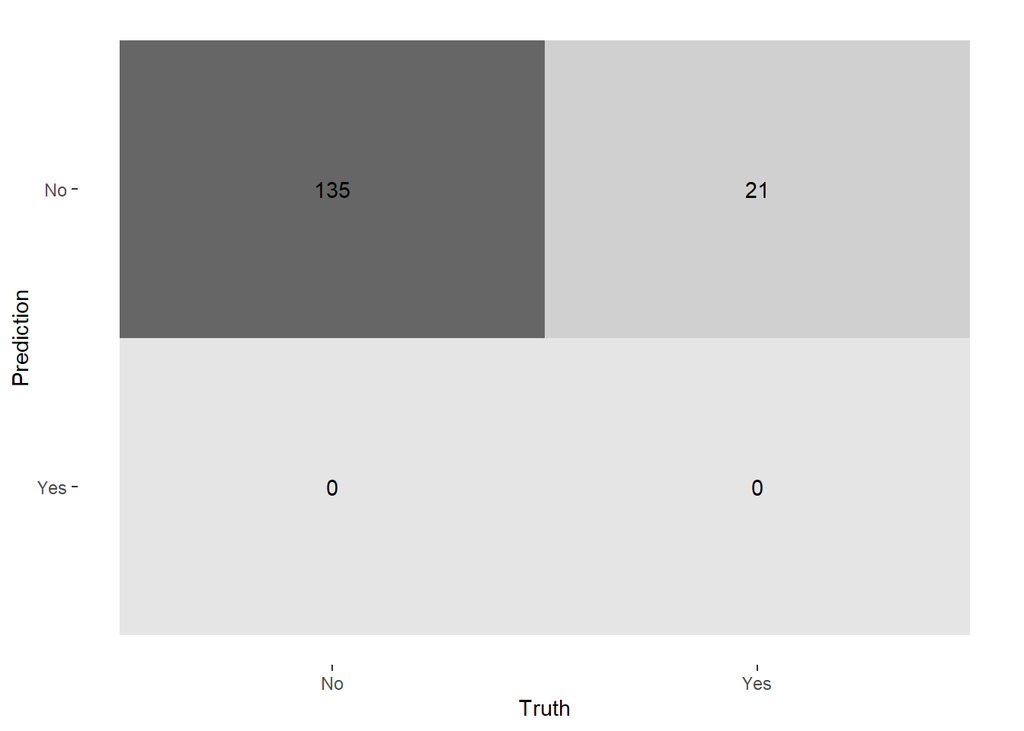

```r
# Based on the CV results without upscaling, elastic net had the highest mean ROC AUC (0.865).
# Extract the best hyperparameters and fit the elastic net model.
best_en_params <- select_best(en_cv, metric = "roc_auc")
final_en_wf <- finalize_workflow(en_wf, best_en_params)
final_fit <- fit(final_en_wf, data = myopia_train)

# Predict on the test set
test_pred <- augment(final_fit, new_data = myopia_test)

# Confusion matrix
test_pred %>%
    conf_mat(truth = myopic, estimate = .pred_class) %>%
    autoplot(type = "heatmap")
```

```r
# ROC AUC of the test (set event_level = "second" because "Yes" is the positive class)
roc_auc(test_pred, truth = myopic, .pred_Yes, event_level = "second")
```

```
## # A tibble: 1 × 3
##   .metric .estimator .estimate
##   <chr>   <chr>          <dbl>
## 1 roc_auc binary         0.869
```

I chose the elastic net model because the elastic model’s ROC AUC was 0.865, the second best was logistic regression at 0.86, LDA at 0.837 and lastly KNN at 0.748.

For context, the ROC AUC measures how well the the model separates the two classes. The higher the AUC the better the model, and the closer to 0.5, the more random the model is.